# 糖尿病预测

```python
# 导入类库
import numpy as np
from matplotlib import pyplot
from pandas import read_csv
from pandas.plotting import scatter_matrix
from pandas import set_option
from sklearn.preprocessing import StandardScaler
from sklearn.model_selection import train_test_split
from sklearn.model_selection import KFold
from sklearn.model_selection import cross_val_score
from sklearn.model_selection import GridSearchCV
from sklearn.metrics import classification_report
from sklearn.metrics import confusion_matrix
from sklearn.metrics import accuracy_score
from sklearn.pipeline import Pipeline
from sklearn.linear_model import LogisticRegression
from sklearn.neighbors import KNeighborsClassifier
from sklearn.tree import DecisionTreeClassifier
from sklearn.discriminant_analysis import LinearDiscriminantAnalysis
from sklearn.naive_bayes import GaussianNB
from sklearn.svm import SVC
from sklearn.ensemble import AdaBoostClassifier
from sklearn.ensemble import GradientBoostingClassifier
from sklearn.ensemble import RandomForestClassifier
from sklearn.ensemble import ExtraTreesClassifier
import warnings
import joblib
warnings.filterwarnings("ignore")
```

## 1.导入数据

### 我们采用的是糖尿病人的基础数据来进行糖尿病人二分类

```python
# 导入数据
filename = 'diabetes.csv'
dataset = read_csv(filename)
```

```python
# 数据维度
print(dataset.shape)
```

```
(768, 9)
```

```python
# 查看是否有缺失值
dataset.info()
```

```
<class 'pandas.core.frame.DataFrame'>
RangeIndex: 768 entries, 0 to 767
Data columns (total 9 columns):
 #   Column                    Non-Null Count  Dtype
---  ------                    --------------  -----
 0   Pregnancies               768 non-null    int64
 1   Glucose                   768 non-null    int64
 2   BloodPressure             768 non-null    int64
 3   SkinThickness             768 non-null    int64
 4   Insulin                   768 non-null    int64
 5   BMI                       768 non-null    float64
 6   DiabetesPedigreeFunction  768 non-null    float64
 7   Age                       768 non-null    int64
 8   Outcome                   768 non-null    int64
dtypes: float64(2), int64(7)
memory usage: 54.1 KB
```

## 2.数据探索

### 查看数据各方面的信息来为我们模型剔除掉干扰项

```python
# 查看数据类型
set_option('display.max_rows', 500)
print(dataset.dtypes)
```

```
Pregnancies                   int64
Glucose                       int64
BloodPressure                 int64
SkinThickness                 int64
Insulin                       int64
BMI                         float64
DiabetesPedigreeFunction    float64
Age                           int64
Outcome                       int64
dtype: object
```

```python
# 查看最初的20条记录
set_option('display.width', 100)
print(dataset.head(20))
```

```
    Pregnancies  Glucose  BloodPressure  SkinThickness  Insulin   BMI  DiabetesPedigreeFunction  \
0             6      148             72             35        0  33.6                     0.627
1             1       85             66             29        0  26.6                     0.351
2             8      183             64              0        0  23.3                     0.672
3             1       89             66             23       94  28.1                     0.167
4             0      137             40             35      168  43.1                     2.288
5             5      116             74              0        0  25.6                     0.201
6             3       78             50             32       88  31.0                     0.248
7            10      115              0              0        0  35.3                     0.134
8             2      197             70             45      543  30.5                     0.158
9             8      125             96              0        0   0.0                     0.232
10            4      110             92              0        0  37.6                     0.191
11           10      168             74              0        0  38.0                     0.537
12           10      139             80              0        0  27.1                     1.441
13            1      189             60             23      846  30.1                     0.398
```

[output cut: 28 more lines]

```python
# 描述性统计信息
set_option('precision', 3)
print(dataset.describe())
```

```
       Pregnancies  Glucose  BloodPressure  SkinThickness  Insulin      BMI  \
count      768.000  768.000        768.000        768.000  768.000  768.000
mean         3.845  120.895         69.105         20.536   79.799   31.993
std          3.370   31.973         19.356         15.952  115.244    7.884
min          0.000    0.000          0.000          0.000    0.000    0.000
25%          1.000   99.000         62.000          0.000    0.000   27.300
50%          3.000  117.000         72.000         23.000   30.500   32.000
75%          6.000  140.250         80.000         32.000  127.250   36.600
max         17.000  199.000        122.000         99.000  846.000   67.100

       DiabetesPedigreeFunction      Age  Outcome
count                   768.000  768.000  768.000
mean                      0.472   33.241    0.349
std                       0.331   11.760    0.477
min                       0.078   21.000    0.000
25%                       0.244   24.000    0.000
50%                       0.372   29.000    0.000
75%                       0.626   41.000    1.000
max                       2.420   81.000    1.000
```

```python
# 数据的分类分布
print(dataset.groupby('Outcome').size())
```

```
Outcome
0    500
1    268
dtype: int64
```

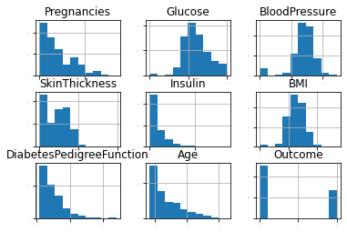

```python
# 直方图
dataset.hist(sharex=False, sharey=False,xlabelsize=1, ylabelsize=1)
pyplot.show()
```

### 可以看到大部分数据呈现高斯分布和指数分布

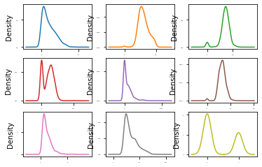

```python
# 密度图
dataset.plot(kind='density', subplots=True, layout=(3,3), sharex=False, legend=False, fontsize=2)
pyplot.show()
```

### 大部分数据都呈现一定的偏态分布,也许可以通过Box-Cox转换提高模型的精确度

### Box-Cox转换时统计中常用的一种数据变化方式,用于连接相应变量不满足正态分布的情况

### 转换之后可以一定程度上减少不可观测的误差

### 也可以预测变量的相关性,将数据转换为正态分布

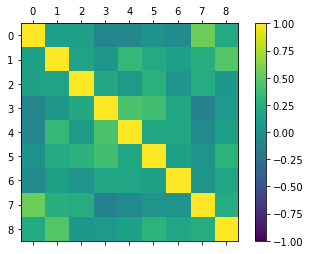

```python
# 关系矩阵图
fig = pyplot.figure()
ax = fig.add_subplot(111)
cax = ax.matshow(dataset.corr(), vmin=-1, vmax=1, interpolation='none')
fig.colorbar(cax)
pyplot.show()
```

### 看到数据之间有的负相关有的正相关.我们需要预测的8和1,5都呈一个比较好的正相关性

## 3.分离评估数据集

### 可以确保分离之后的数据集和训练模型完全隔离,有助于判断模型的精确度

### 我们分离80的数据作为训练集 20作为训练集

```python
# 分离评估数据集
array = dataset.values
X = array[:, 0:8].astype(float)
Y = array[:, 8]
validation_size = 0.2
seed = 7
X_train, X_validation, Y_train, Y_validation = train_test_split(X, Y, test_size=validation_size, random_state=seed)
```

```python
# 评估算法的基准
num_folds = 10
seed = 7
scoring = 'accuracy'
```

## 4.评估算法模型

### 分析完成后,并不能确定哪个模型是最佳的模型

### 因此需要一个评估框架来帮助我们选择合适的算法

### 对所有算法都不进行调参 通过默认参数来进行训练和比较

### 通过对比准确的平均值和标准方差来比较算法

```python
# 评估算法
models = {}
models['LR'] = LogisticRegression()
models['LDA'] = LinearDiscriminantAnalysis()
models['KNN'] = KNeighborsClassifier()
models['CART'] = DecisionTreeClassifier()
models['NB'] = GaussianNB()
models['SVM'] = SVC()
results = []
for key in models:
    kfold = KFold(n_splits=num_folds, random_state=seed)
    cv_results = cross_val_score(models[key], X_train, Y_train, cv=kfold, scoring=scoring)
    results.append(cv_results)
    print('%s : %f (%f)' % (key, cv_results.mean(), cv_results.std()))
```

```
LR : 0.775172 (0.058545)
LDA : 0.773559 (0.058283)
KNN : 0.710153 (0.064599)
CART : 0.669408 (0.048839)
NB : 0.750820 (0.050575)
SVM : 0.757271 (0.047915)
```

#### 这只是10折交叉验证的结果,还需要看一下每一次得出的结果的分布情况

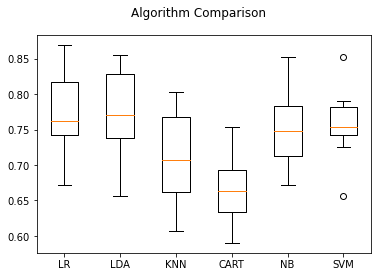

```python
# 评估算法 - 箱线图
fig = pyplot.figure()
fig.suptitle('Algorithm Comparison')
ax = fig.add_subplot(111)
pyplot.boxplot(results)
ax.set_xticklabels(models.keys())
pyplot.show()
```

#### 有些数据可能分布不均匀,这里我们将数据进行正态化处理,在进行一次比较

```python
# 评估算法 - 正态化数据
pipelines = {}
pipelines['ScalerLR'] = Pipeline([('Scaler', StandardScaler()), ('LR', LogisticRegression())])
pipelines['ScalerLDA'] = Pipeline([('Scaler', StandardScaler()), ('LDA', LinearDiscriminantAnalysis())])
pipelines['ScalerKNN'] = Pipeline([('Scaler', StandardScaler()), ('KNN', KNeighborsClassifier())])
pipelines['ScalerCART'] = Pipeline([('Scaler', StandardScaler()), ('CART', DecisionTreeClassifier())])
pipelines['ScalerNB'] = Pipeline([('Scaler', StandardScaler()), ('NB', GaussianNB())])
pipelines['ScalerSVM'] = Pipeline([('Scaler', StandardScaler()), ('SVM', SVC())])
results = []
for key in pipelines:
    kfold = KFold(n_splits=num_folds, random_state=seed)
    cv_results = cross_val_score(pipelines[key], X_train, Y_train, cv=kfold, scoring=scoring)
    results.append(cv_results)
    print('%s : %f (%f)' % (key, cv_results.mean(), cv_results.std()))
```

```
ScalerLR : 0.778424 (0.061895)
ScalerLDA : 0.773559 (0.058283)
ScalerKNN : 0.718297 (0.071563)
ScalerCART : 0.675833 (0.053208)
ScalerNB : 0.750820 (0.050575)
ScalerSVM : 0.752565 (0.064295)
```

#### 可以看到LR算法有着不错的结果

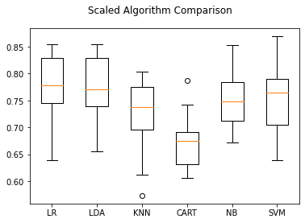

```python
# 评估算法 - 箱线图
fig = pyplot.figure()
fig.suptitle('Scaled Algorithm Comparison')
ax = fig.add_subplot(111)
pyplot.boxplot(results)
ax.set_xticklabels(models.keys())
pyplot.show()
```

## 5.算法调参

### 我们对表现还不错的模型进行调参,进一步提高算法精度

```python
# 调参改进算法 - LR ('C'为LR算法的超参数)
scaler = StandardScaler().fit(X_train)
rescaledX = scaler.transform(X_train)
param_grid = {'C': [0.1, 5, 13, 15]}
model = LogisticRegression()
kfold = KFold(n_splits=num_folds, random_state=seed)
grid = GridSearchCV(estimator=model, param_grid=param_grid, scoring=scoring, cv=kfold)
grid_result = grid.fit(X=rescaledX, y=Y_train)

print('最优：%s 使用%s' % (grid_result.best_score_, grid_result.best_params_))
cv_results = zip(grid_result.cv_results_['mean_test_score'],
                 grid_result.cv_results_['std_test_score'],
                 grid_result.cv_results_['params'])
for mean, std, param in cv_results:
    print('%f (%f) with %r' % (mean, std, param))
```

```
最优：0.780037017451084 使用{'C': 5}
0.768667 (0.066177) with {'C': 0.1}
0.780037 (0.061129) with {'C': 5}
0.780037 (0.061129) with {'C': 13}
0.780037 (0.061129) with {'C': 15}
```

```python
# 调参改进算法 - LDA('tol'为SVM算法的超参数)
scaler = StandardScaler().fit(X_train)
rescaledX = scaler.transform(X_train).astype(float)
param_grid = {}
param_grid['tol'] = [0.1,0.2,0.3,0.4,0.5,0.6,0.7,0.8,0.9,1]
param_grid['solver'] = ['svd','lsqr','eigen']
model = LinearDiscriminantAnalysis()
kfold = KFold(n_splits=num_folds, random_state=seed)
grid = GridSearchCV(estimator=model, param_grid=param_grid, scoring=scoring, cv=kfold)
grid_result = grid.fit(X=rescaledX, y=Y_train)

print('最优：%s 使用%s' % (grid_result.best_score_, grid_result.best_params_))
cv_results = zip(grid_result.cv_results_['mean_test_score'],
                 grid_result.cv_results_['std_test_score'],
                 grid_result.cv_results_['params'])
for mean, std, param in cv_results:
    print('%f (%f) with %r' % (mean, std, param))
```

```
最优：0.7735589635113697 使用{'solver': 'svd', 'tol': 0.1}
0.773559 (0.058283) with {'solver': 'svd', 'tol': 0.1}
0.773559 (0.058283) with {'solver': 'svd', 'tol': 0.2}
0.773559 (0.058283) with {'solver': 'svd', 'tol': 0.3}
0.773559 (0.058283) with {'solver': 'svd', 'tol': 0.4}
0.773559 (0.058283) with {'solver': 'svd', 'tol': 0.5}
0.773559 (0.058283) with {'solver': 'svd', 'tol': 0.6}
0.765442 (0.063001) with {'solver': 'svd', 'tol': 0.7}
0.763829 (0.064190) with {'solver': 'svd', 'tol': 0.8}
0.742597 (0.056767) with {'solver': 'svd', 'tol': 0.9}
0.656293 (0.044581) with {'solver': 'svd', 'tol': 1}
0.773559 (0.058283) with {'solver': 'lsqr', 'tol': 0.1}
0.773559 (0.058283) with {'solver': 'lsqr', 'tol': 0.2}
0.773559 (0.058283) with {'solver': 'lsqr', 'tol': 0.3}
0.773559 (0.058283) with {'solver': 'lsqr', 'tol': 0.4}
0.773559 (0.058283) with {'solver': 'lsqr', 'tol': 0.5}
0.773559 (0.058283) with {'solver': 'lsqr', 'tol': 0.6}
0.773559 (0.058283) with {'solver': 'lsqr', 'tol': 0.7}
0.773559 (0.058283) with {'solver': 'lsqr', 'tol': 0.8}
0.773559 (0.058283) with {'solver': 'lsqr', 'tol': 0.9}
0.773559 (0.058283) with {'solver': 'lsqr', 'tol': 1}
0.773559 (0.058283) with {'solver': 'eigen', 'tol': 0.1}
0.773559 (0.058283) with {'solver': 'eigen', 'tol': 0.2}
0.773559 (0.058283) with {'solver': 'eigen', 'tol': 0.3}
0.773559 (0.058283) with {'solver': 'eigen', 'tol': 0.4}
0.773559 (0.058283) with {'solver': 'eigen', 'tol': 0.5}
0.773559 (0.058283) with {'solver': 'eigen', 'tol': 0.6}
0.773559 (0.058283) with {'solver': 'eigen', 'tol': 0.7}
0.773559 (0.058283) with {'solver': 'eigen', 'tol': 0.8}
0.773559 (0.058283) with {'solver': 'eigen', 'tol': 0.9}
0.773559 (0.058283) with {'solver': 'eigen', 'tol': 1}
```

### LAD没有提升的空间了,已经是最优

```python
# 调参改进算法 - SVM ('C'为SVM算法的超参数)
scaler = StandardScaler().fit(X_train)
rescaledX = scaler.transform(X_train).astype(float)
param_grid = {}
param_grid['C'] = [0.1, 0.3, 0.5, 0.7, 0.9, 1.0, 1.3, 1.5, 1.7, 2.0]
param_grid['kernel'] = ['linear', 'poly', 'rbf', 'sigmoid']
model = SVC()
kfold = KFold(n_splits=num_folds, random_state=seed)
grid = GridSearchCV(estimator=model, param_grid=param_grid, scoring=scoring, cv=kfold)
grid_result = grid.fit(X=rescaledX, y=Y_train)

print('最优：%s 使用%s' % (grid_result.best_score_, grid_result.best_params_))
cv_results = zip(grid_result.cv_results_['mean_test_score'],
                 grid_result.cv_results_['std_test_score'],
                 grid_result.cv_results_['params'])
for mean, std, param in cv_results:
    print('%f (%f) with %r' % (mean, std, param))
```

```
最优：0.7800898995240614 使用{'C': 0.1, 'kernel': 'linear'}
0.780090 (0.055426) with {'C': 0.1, 'kernel': 'linear'}
0.711608 (0.066320) with {'C': 0.1, 'kernel': 'poly'}
0.711713 (0.047940) with {'C': 0.1, 'kernel': 'rbf'}
0.765362 (0.059384) with {'C': 0.1, 'kernel': 'sigmoid'}
0.780063 (0.060190) with {'C': 0.3, 'kernel': 'linear'}
0.731280 (0.054733) with {'C': 0.3, 'kernel': 'poly'}
0.754045 (0.067017) with {'C': 0.3, 'kernel': 'rbf'}
0.750714 (0.060719) with {'C': 0.3, 'kernel': 'sigmoid'}
0.778451 (0.061394) with {'C': 0.5, 'kernel': 'linear'}
0.736118 (0.072612) with {'C': 0.5, 'kernel': 'poly'}
0.754098 (0.069671) with {'C': 0.5, 'kernel': 'rbf'}
0.762110 (0.042649) with {'C': 0.5, 'kernel': 'sigmoid'}
0.778451 (0.061394) with {'C': 0.7, 'kernel': 'linear'}
0.739397 (0.063104) with {'C': 0.7, 'kernel': 'poly'}
0.745955 (0.060212) with {'C': 0.7, 'kernel': 'rbf'}
0.747462 (0.050255) with {'C': 0.7, 'kernel': 'sigmoid'}
0.778451 (0.061394) with {'C': 0.9, 'kernel': 'linear'}
0.737811 (0.060544) with {'C': 0.9, 'kernel': 'poly'}
0.749260 (0.064707) with {'C': 0.9, 'kernel': 'rbf'}
0.722951 (0.055590) with {'C': 0.9, 'kernel': 'sigmoid'}
0.778451 (0.061394) with {'C': 1.0, 'kernel': 'linear'}
0.739476 (0.058420) with {'C': 1.0, 'kernel': 'poly'}
0.747673 (0.061555) with {'C': 1.0, 'kernel': 'rbf'}
0.718139 (0.047951) with {'C': 1.0, 'kernel': 'sigmoid'}
0.778451 (0.061394) with {'C': 1.3, 'kernel': 'linear'}
0.742729 (0.058843) with {'C': 1.3, 'kernel': 'poly'}
0.742755 (0.058317) with {'C': 1.3, 'kernel': 'rbf'}
0.716446 (0.044934) with {'C': 1.3, 'kernel': 'sigmoid'}
0.778451 (0.061394) with {'C': 1.5, 'kernel': 'linear'}
0.744342 (0.058636) with {'C': 1.5, 'kernel': 'poly'}
0.742702 (0.059437) with {'C': 1.5, 'kernel': 'rbf'}
0.690375 (0.052174) with {'C': 1.5, 'kernel': 'sigmoid'}
0.778451 (0.061394) with {'C': 1.7, 'kernel': 'linear'}
0.747594 (0.062618) with {'C': 1.7, 'kernel': 'poly'}
0.736145 (0.059626) with {'C': 1.7, 'kernel': 'rbf'}
0.706716 (0.052832) with {'C': 1.7, 'kernel': 'sigmoid'}
0.776811 (0.060926) with {'C': 2.0, 'kernel': 'linear'}
0.749180 (0.065297) with {'C': 2.0, 'kernel': 'poly'}
0.736118 (0.061380) with {'C': 2.0, 'kernel': 'rbf'}
0.693654 (0.062248) with {'C': 2.0, 'kernel': 'sigmoid'}
```

### SVM也提升到了78%左右,可喜可贺

## 6.集成算法

### 除了调参之外,集成学习也可以进一步提高准确度

### 袋装算法:随机森林RF 极端随机树ET

### 提升算法:AdaBoost 随机梯度上升GBM

```python
# 集成算法
ensembles = {}
ensembles['ScaledAB'] = Pipeline([('Scaler', StandardScaler()), ('AB', AdaBoostClassifier())])
ensembles['ScaledGBM'] = Pipeline([('Scaler', StandardScaler()), ('GBM', GradientBoostingClassifier())])
ensembles['ScaledRF'] = Pipeline([('Scaler', StandardScaler()), ('RFR', RandomForestClassifier())])
ensembles['ScaledET'] = Pipeline([('Scaler', StandardScaler()), ('ETR', ExtraTreesClassifier())])
results = []
for key in ensembles:
    kfold = KFold(n_splits=num_folds, random_state=seed)
    cv_result = cross_val_score(ensembles[key], X_train, Y_train, cv=kfold, scoring=scoring)
    results.append(cv_result)
    print('%s: %f (%f)' % (key, cv_result.mean(), cv_result.std()))
```

```
ScaledAB: 0.724775 (0.063334)
ScaledGBM: 0.747435 (0.082235)
ScaledRF: 0.755605 (0.065204)
ScaledET: 0.745955 (0.060557)
```

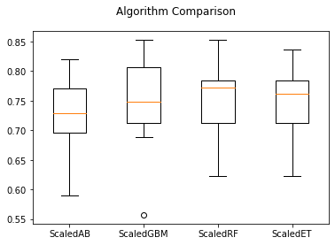

```python
# 集成算法 - 箱线图
fig = pyplot.figure()
fig.suptitle('Algorithm Comparison')
ax = fig.add_subplot(111)
pyplot.boxplot(results)
ax.set_xticklabels(ensembles.keys())
pyplot.show()
```

```python
# 集成算法GBM - 调参
scaler = StandardScaler().fit(X_train)
rescaledX = scaler.transform(X_train)
param_grid = {'n_estimators': [10, 50, 100, 200, 300, 400, 500, 600, 700, 800, 900]}
model = GradientBoostingClassifier()
kfold = KFold(n_splits=num_folds, random_state=seed)
grid = GridSearchCV(estimator=model, param_grid=param_grid, scoring=scoring, cv=kfold)
grid_result = grid.fit(X=rescaledX, y=Y_train)
print('最优：%s 使用%s' % (grid_result.best_score_, grid_result.best_params_))
```

```
最优：0.7523532522474882 使用{'n_estimators': 50}
```

## 7.确定最终模型

```python
# 模型最终化
scaler = StandardScaler().fit(X_train)
rescaledX = scaler.transform(X_train)
model = SVC(C=0.1, kernel='linear')
model.fit(X=rescaledX, y=Y_train)
```

```
SVC(C=0.1, kernel='linear')
```

```python
# 模型保存
joblib.dump(model,"model.pkl")
```

```
['model.pkl']
```

### accuracy_score 代表了准确率,但是在正负样本不均衡时效果不佳,严格比较lable标签Y_validation, predictions

### confusion_matrix 混淆矩阵中的误差矩阵类)

[figure not shown]

### precision：精度=正确预测的个数(TP)/被预测正确的个数(TP+FP)；人话也就是模型预测的结果中有多少是预测正确的

### recall:召回率=正确预测的个数(TP)/预测个数(TP+FN)；人话也就是某个类别测试集中的总量，有多少样本预测正确了

### f1-score:F1 = 2*精度*召回率/(精度+召回率)

```python
# 评估模型
rescaled_validationX = scaler.transform(X_validation)
predictions = model.predict(rescaled_validationX)
print(accuracy_score(Y_validation, predictions))
print(confusion_matrix(Y_validation, predictions))
print(classification_report(Y_validation, predictions))
```

```
0.7922077922077922
[[91  6]
 [26 31]]
              precision    recall  f1-score   support

         0.0       0.78      0.94      0.85        97
         1.0       0.84      0.54      0.66        57

    accuracy                           0.79       154
   macro avg       0.81      0.74      0.76       154
weighted avg       0.80      0.79      0.78       154
```

### 精确度居然还有提升的空间,在测试集上有了很不错的效果达到了0.7922